# «Сравнительный анализ сетевых возможностей Windows и Linux»

Презентация

преподаватель - Дмитрий Сергеевич Кулябов, д.ф.-м.н., профессор кафедры теории вероятностей и кибербезопасности

kulyabov-ds@rudn.ru

студент - Гайдук Софья Сергеевна

1032253645@rudn.ru

2026-04-15

### Информация

### Докладчик

- Гайдук Софья Сергеевна
- студент
- направление Прикладная информатика
- Российский университет дружбы народов им. П. Лумумбы
- 1032253645@rudn.ru
- https://https://github.com/SofiaGayduk/study_2025-2026_os-intro
- https://gitverse.ru/SofiaGayduk/study_2025-2026_os-intro

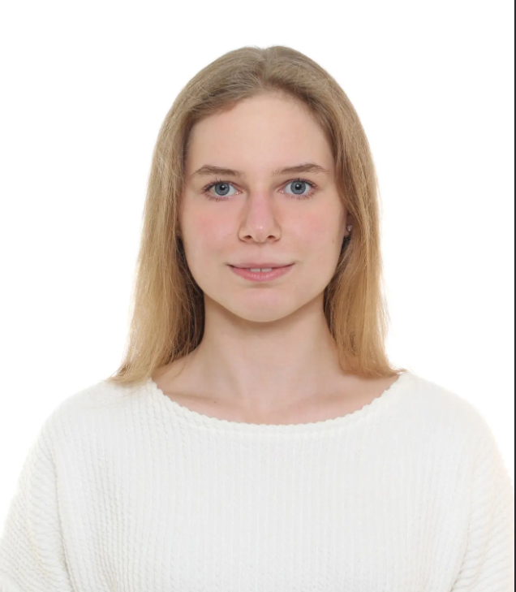

## Вводная часть

**Актуальность темы:** выбор операционной системы для сетевых задач определяет производительность, безопасность и стоимость владения.

**Объект исследования:** сетевые подсистемы ОС Windows Server 2022 / Windows 11 и Linux (ядро 6.x, дистрибутив Fedora Server 40 / Fedora Workstation 40).

**Предмет исследования:** протоколы, стек TCP/IP, утилиты, безопасность, масштабируемость.

**Научная новизна:** в работе проведён системный сравнительный анализ по пропускной способности, командам и по параметрам «сетевая программируемость», «встроенные средства наблюдения eBPF / Netlink / PowerShell», маршрутизация, балансировка, изоляция контейнеров.

**Практическая значимость:** Результаты позволяют программистам обоснованно выбирать ОС

## Цель, гипотеза

**Цель:** Выявить принципиальные различия и сильные стороны сетевых возможностей Windows и Linux, дать рекомендации по выбору ОС под конкретные сетевые сценарии.

**Гипотеза:** Linux обладает более гибким, настраиваемым и производительным сетевым стеком для высоконагруженных и нестандартных сценариев, Windows предоставляет более интегрированное и простое в администрировании решение для сетей на основе Active Directory и централизованной политики.

## Задачи исследования

1. Провести сравнительный анализ стека TCP/IP (реализация, настройка параметров).
2. Сравнить инструментарий командной строки и GUI.
3. Оценить производительность на типовых сетевых нагрузках (файловый сервер, маршрутизация, VPN).
4. Исследовать сетевую безопасность (брандмауэр, изоляция, аудит).
5. Сравнить поддержку контейнеризации и виртуальных сетей.
6. Сформулировать рекомендации по выбору ОС в зависимости от задачи.

### Материалы, методы и инструменты исследования, теоретическая база

**Теоретическая база:** Стандарты RFC (TCP/IP), документация Microsoft (Windows Filtering Platform, NDIS), документация Linux (man pages, Kernel Networking, Netfilter, eBPF), сравнительные обзоры (SPEC, Phoronix).

**Материалы и оборудование:** Два стенда с идентичным железом (2×Xeon, 10GbE).  
ОС: Windows Server 2022, Fedora Server 40 (ядро 6.8.8-200).

**Методы:**

- Эмпирический (замеры iperf3, netperf, ping, traceroute).
- Сравнительный анализ (функции, инструменты, сложность настройки).
- Анализ документации и системных вызовов.
- Моделирование сетевых сценариев (NAT, bridging, bonding).

**Инструменты:**

iperf3 (ntttcp), nload, tcpdump, Wireshark, ethtool, Get-NetAdapter, netsh, nettrace, PerfView, bpftrace, ss, netstat.

### Содержание исследования

**Предлагаемое решение задач исследования с обоснованием (Windows/Linux (Fedora)):**

- Протоколы и стек TCP/IP
- Маршрутизация и фильтрация
- Мониторинг и отладка
- Агрегация каналов (Bonding / Teaming)
- Контейнеры и виртуализация

#### Анализ и практическая значимость достигнутых результатов

| Параметр | Windows | Linux (Fedora) |
| --- | --- | --- |
| Гибкость настройки TCP/IP | Средняя (реестр / WMI) | Высокая (sysctl) |
| Производительность RAW‑сокетов | Низкая (ограничения) | Высокая (PACKET_MMAP, AF_XDP) |
| Брандмауэр (сложные сценарии) | Сложно (WFP) | Гибко (nftables) |
| Диагностика сети | Удобно для AD | Максимально детально (eBPF) |
| Поддержка контейнерной сети | Базовая (NAT, l2bridge) | Полная (Overlay, Macvlan, Podman) |
| Встроенная маршрутизация | RRAS — ограниченная | Промышленная (FRRouting) |
| Простота для малого офиса (LAN) | Высокая (мастер, общие ресурсы) | Средняя (CLI, Samba, Cockpit) |

### Общее заключение и выводы

1. Linux (Fedora) превосходит Windows в производительности сетевого стека при высоких нагрузках, предлагает полный контроль, открытые инструменты (eBPF, tc, nftables), идеально подходит для инфраструктурных сетевых устройств.
2. Windows выигрывает в корпоративной среде с Active Directory: простота настройки общих ресурсов, встроенная система политик безопасности, удобный GUI для базовых операций.
3. Для смешанных сценариев Windows проще, но при малейших требованиях к нестандартной маршрутизации или отладке пакетов Linux оказывается эффективнее.
4. Рекомендация:
   - Windows - терминальные серверы, файловые серверы, управляемые доменные сети.
   - Linux - маршрутизаторы, шлюзы безопасности, хостинг, облачные платформы, контейнерные среды.

Таким образом, гипотеза подтвердилась: Linux — для сетевой инженерии и производительности, Windows — для управляемости и простоты в стандартных офисных сетях.

#### Список литературы

- Microsoft Corporation (2023). *Description of Windows TCP features*. Microsoft Learn. URL: https://learn.microsoft.com/en-us/troubleshoot/windows-server/networking/description-tcp-features
- The Linux Kernel Community (2024). *Linux Kernel Networking Documentation*. The Linux Kernel Archives. URL: https://www.kernel.org/doc/html/v6.7/networking/index.html
- Microsoft Corporation (2023). *Описание функций Windows TCP*. Microsoft Learn. URL: https://learn.microsoft.com/ru-ru/troubleshoot/windows-server/networking/description-tcp-features
- OpenBenchmarking.org (2024). *iPerf 3.14 Benchmark Results*. URL: https://mail.openbenchmarking.org/result/2406240-K635-MERGENE99
- Microsoft Corporation (2018). *MSFT_NetTCPSetting class*. GitHub /MicrosoftDocs. URL: https://github.com/MicrosoftDocs/win32/blob/docs/desktop-src/FWP/wmi/nettcpipprov/msft-nettcpsetting.md
- The Linux Kernel Community (2020). *Linux Ethernet Bonding Driver HOWTO*. The Linux Kernel Archives. URL: https://www.kernel.org/doc/html/v5.9/networking/team.html
- Материалы к лекции №6. RUDN. https://esystem.rudn.ru/mod/folder/view.php?id=1358508